# Session 11: Causal Inference (2/2)

Published course presentation · repository edition

Thierry Warin, PhD

HEC Montréal

## Outline · The hour ahead

1. The key concept
2. A Difference-in-Difference model
3. Instrumental Variables: Your turn!
4. Conclusion

## What session 11 is for

### The mathematics

- Set up a **difference-in-differences** design and identify the four cells
- Read the **interaction coefficient** as the estimate
- State the **parallel-trends** assumption and how you would probe it
- Say what an **instrument** must satisfy, and why good ones are rare

## Your Python so far

Everything you need to type is on one sheet — how to start Python in VS Codium on your platform, how to make a file and run it, the DataFrame basics, and every name from sessions 1 to 11, each with a line showing it in use.

> **[Python Cheatsheet · Session 11](https://warint.github.io/quantitative-methods/python-cheatsheet-11.pdf)** (PDF) · in the repository at `11-…/PYTHON-CHEATSHEET.pdf`

**One sheet per package, functions explained with pictures:** [pandas](https://warint.github.io/quantitative-methods/python-cheatsheets/pandas.pdf) · [NumPy](https://warint.github.io/quantitative-methods/python-cheatsheets/numpy.pdf) · [matplotlib](https://warint.github.io/quantitative-methods/python-cheatsheets/matplotlib.pdf) · [statsmodels](https://warint.github.io/quantitative-methods/python-cheatsheets/statsmodels.pdf)

Print it, or keep it open beside the editor. Nothing on it is examinable; all of it is assumed.

## The key concept

## The key concept

The difference-in-difference model is used to estimate the effect of a policy intervention or treatment by comparing changes over time in an outcome for a treated group to changes over time for a comparison (control) group.

1. It measures how the mean of an outcome changes before and after treatment for the treatment group.
2. It compares this change with the mean change over time for a control group that is not exposed to the treatment.

We observe average outcomes for two groups, before and after the intervention.

## The key concept (cont.)

Difference in difference model

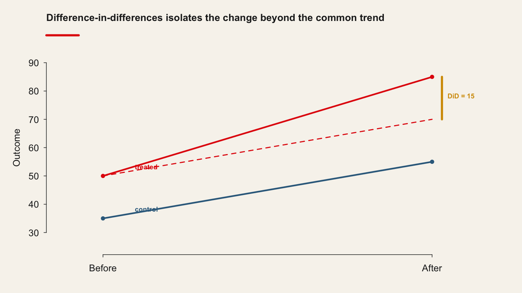

## The key concept (cont.)

The DiD estimator is the difference between the average change in the treatment group and the average change in the control group:

$$(\text{Treatment_post} - \text{Treatment_pre}) - (\text{Control_post} - \text{Control_pre}) = \widehat{\text{DiD}}$$

$$(85 - 50) - (55 - 35) = 15$$

## The key concept (cont.)

A more detailed representation is shown in the following table.

Difference in difference, an example

[figure not shown]

## The key concept (cont.)

In this simple DiD setup:

> - We work with grouped data, comparing a treatment and a control group.
> - Coefficients represent group means and differences between group means; there is no time trend slope as in a standard time series regression.

## The statistical model

A basic DiD model can be written as:

$$Y = \beta_0 + \beta_1 \cdot \text{Treatment} + \beta_2 \cdot \text{Post} + \beta_3 \cdot (\text{Treatment} \times \text{Post}) + e$$

## The statistical model (cont.)

A schematic dataset for a simple DiD design is:

| Subject | Outcome | Treatment | Post | Treatment × Post |
| --- | --- | --- | --- | --- |
| 1 | 74 | 1 | 1 | 1 |
| 1 | 46 | 1 | 0 | 0 |
| 2 | 96 | 1 | 1 | 1 |
| 2 | 54 | 1 | 0 | 0 |
| 3 | 50 | 0 | 1 | 0 |
| 3 | 30 | 0 | 0 | 0 |
| 4 | 60 | 0 | 1 | 0 |
| 4 | 40 | 0 | 0 | 0 |

Two units belong to the treatment group and two units to the control group. For each unit there is one observation before and one observation after the treatment.

## The coefficients

| **Dependent variable:** Outcome | Estimate | Std. Error |
| --- | --- | --- |
| **Intercept (B0)** | 35.00*** | (0.00) |
| **Treatment (B1)** | 15.00*** | (0.00) |
| **Post-treatment (B2)** | 20.00*** | (0.00) |
| **Diff in Diff (B3)** | 15.00*** | (0.00) |

**Note:** p<0.1; p<0.05; p<0.01

## The coefficients (cont.)

Each coefficient corresponds to a group mean or a difference between group means.

- $\beta_0$ is the average outcome of the control group before treatment.
- $\beta_1$ is the difference between the treatment and control group in the pre-treatment period. In the example, $\beta_1 = 15$, so $\beta_0 + \beta_1 = 50$, the pre-treatment mean for the treatment group.
- $\beta_2$ captures the change in the average outcome of the control group from the pre-treatment to the post-treatment period. The post-treatment mean for the control group is $\beta_0 + \beta_2$.
- $\beta_3$ is the DiD estimator: it measures how much the average outcome in the treatment group changes in the post-treatment period relative to what would have happened in the absence of treatment.

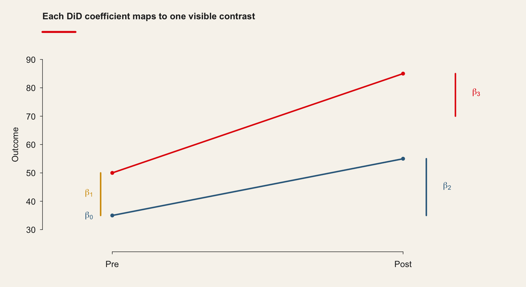

## The coefficients (cont.)

To obtain the post-treatment mean for the treatment group, we add:

$$\beta_0 + \beta_1 + \beta_2 + \beta_3$$

Each coefficient corresponds to a distinct hypothesis:

| Coefficient | Hypothesis |
| --- | --- |
| $\beta_0$ | Is the average outcome of the control group before treatment different from 0? |
| $\beta_1$ | Is the pre-treatment difference between treatment and control groups different from 0? |
| $\beta_2$ | Is the change over time in the control group different from 0? |
| $\beta_3$ | DiD estimator: does the treatment have an effect? |

## The counterfactual

To interpret $\beta_3$, it is useful to consider the counterfactual.

The counterfactual is the outcome the treatment group would have experienced in the absence of the policy intervention. In the DiD framework, the counterfactual is inferred from the time trend observed in the control group.

## The counterfactual (cont.)

DID counterfactual

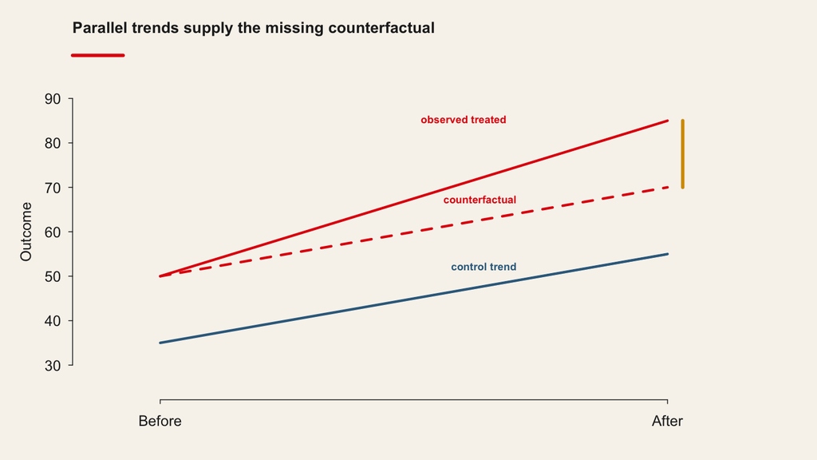

## The counterfactual (cont.)

Using the simple four-cell example:

$$(\text{Treatment_post} - \text{Treatment_pre}) = (\text{Control_post} - \text{Control_pre}) \\ (X - 50) = (55 - 35) \\ (X - 50) = 20 \\ X = 20 + 50 = 70$$

So the counterfactual outcome for the treatment group in the post-treatment period is 70.

## The counterfactual (cont.)

Using the regression coefficients, the counterfactual can also be written as:

$$\text{Counterfactual} = \beta_0 + \beta_1 + \beta_2$$

## A Difference-in-Difference model

## A Difference-in-Difference model

Figure 1: A housing project in New York

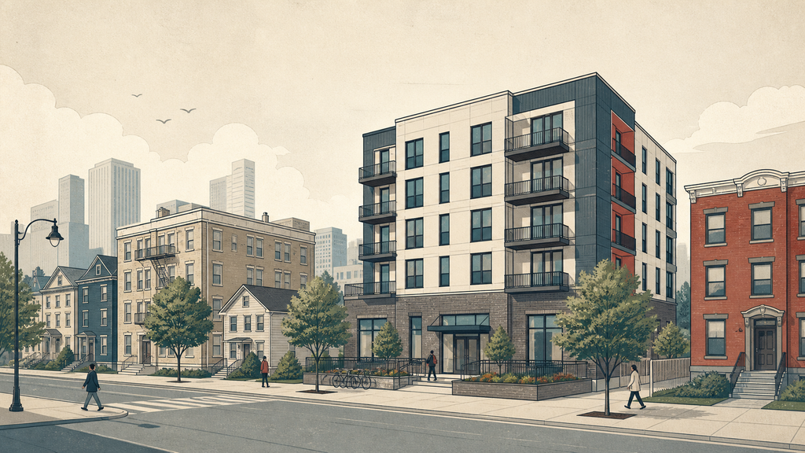

Governments at different levels subsidize housing projects to create affordable dwellings. This policy has gained prominence as housing costs have increased in many cities.

Critics of such programs often argue that the construction of affordable housing may reduce nearby property values. Possible mechanisms include:

- Neighborhood preferences for proximity to high-income households
- Congestion effects due to higher local population
- Architectural mismatch between new projects and the existing housing stock

## A Difference-in-Difference model (cont.)

A DiD design can be used to examine whether housing projects reduce nearby house prices, as in Ellen et al. (2007).

We simulate data on housing prices for:

- Houses located close to a subsidized housing project (treatment group)
- Houses located far from such projects (control group)

## A Difference-in-Difference model (cont.)

Prices are observed before and after the construction of the subsidized housing site.

> **Research question:** Do affordable housing projects reduce the prices of nearby houses?

> **Hypothesis:** Houses near subsidized housing projects experience a larger decrease in prices over time.

## Data

```python
# In the VS Codium terminal, with .venv active:  python
import pandas as pd

data = pd.DataFrame({
    "House_Price": [213679.8, 229355.4, 190580.1, 188669.0, 253573.7,
                    320094.0, 188525.7, 282998.4, 184424.0, 290409.4],
    "Group":          [0, 0, 1, 1, 0, 0, 1, 1, 0, 0],   # 1 = treated area
    "Post_Treatment": [0, 1, 0, 1, 0, 1, 0, 1, 0, 1],   # 1 = after the policy
})

data
```

[output not shown]

Variables:

- `House_Price`: house price
- `Group`: 1 if close to a subsidized housing site, 0 otherwise
- `Post_Treatment`: 1 if observed after the site opens, 0 otherwise

## Analysis

The DiD regression is:

$$Y = \beta_0 + \beta_1 \cdot \text{Group} + \beta_2 \cdot \text{Post_Treatment} + \beta_3 \cdot (\text{Group} \times \text{Post_Treatment}) + e$$

```python
import statsmodels.formula.api as smf

# The interaction IS the difference-in-differences estimate
reg_housing = smf.ols("House_Price ~ Group * Post_Treatment", data=data).fit()

print(reg_housing.summary())
print(f"\nDiD estimate = {reg_housing.params['Group:Post_Treatment']:+,.0f}")
```

## The interaction IS the difference-in-differences estimate (cont.)

[output not shown]

## Discussion of the results

With the housing example, the main questions are:

- Is the average price in the control group at time 1 different from zero?
- Did the treatment and control groups differ in average price at time 1?
- Did the control group experience a significant change in average price between time 1 and time 2?
- Does the treatment group at time 2 differ from its counterfactual?

## Instrumental Variables: Your turn!

## Instrumental Variables: Your turn!

- https://rpubs.com/Sternonyos/913599

```python
data = pd.DataFrame({
    "Treatment":  [1, 0, 1, 1, 1, 0, 0, 1, 0, 1],
    "age":        [75, 62, 60, 60, 57, 55, 50, 48, 60, 51],
    "sex":        [1, 2, 1, 2, 2, 2, 2, 2, 1, 2],
    "education":  [3, 2, 1, 2, 1, 1, 1, 2, 2, 2],
    "marital":    [4, 4, 4, 4, 4, 4, 4, 4, 3, 3],
    "information":[1, 1, 1, 1, 1, 1, 1, 1, 1, 1],
    "income":     [3000, 3000, 11000, 1000, 1000, 4000, 3000, 2000, 2000, 3000],
    "newvar":     [1.45, 1.00, 1.45, 1.45, 1.45, 1.00, 1.00, 1.45, 1.00, 1.45],
    "info_index": [2.2967648, -0.6487551, 1.5254940, 1.5254940, 1.3712398,
                   -0.7515912, -0.8250455, 0.9084774, -0.6781368, 1.0627315],
})

data
```

[output not shown]

## Conclusion

## Conclusion

- The difference-in-difference model is a powerful tool for estimating causal effects in observational data.
- It relies on the parallel trends assumption, which must be carefully considered and validated.
- Proper data structuring and interpretation of coefficients are crucial for accurate analysis.
- DiD models can be extended to include multiple time periods, covariates, and more complex designs.
- Always visualize your data and results to ensure the validity of your findings.
- IV models are another tool for causal inference when endogeneity is a concern.
- Continue practicing with real-world datasets to solidify your understanding of these methods.

## Conclusion (cont.)

- You have now an incredible toolbox to analyse social and business phenomena! I am really proud of you! You will change the world!

## Before the next session

**Required:** the next session’s article, its Dataverse package, and the self-check. That is the pre-session deck.

**Optional:** the **QMIB Lab** for this session — a knowledge check on the hour you have just sat through: **[warin.ca/qmib-labs](https://warin.ca/qmib-labs/qmib-lab-11.html)**

Never a prerequisite, never marked for correctness. A completed report counts toward participation because attempting it is the engagement being measured.